# Fashion Retail Capstone — Classification, Clustering & NLP on Customer Reviews

## Task 4 — Classification on Imbalanced Data

**Which class counts as the "positive" one?** The label column is `Recommended IND`, exactly as specified. But the *event the business cares about* is the minority class — the customer who would **not** recommend. Every precision / recall / F1 number in Tasks 4 and 5 is therefore computed with respect to **class 0**, and a "false negative" means *a genuinely dissatisfied customer we failed to flag*. Accuracy and ROC-AUC are class-symmetric and unaffected by that choice.

Five rows are compared: a majority-class baseline, plus Logistic Regression and Random Forest, each trained twice — once with `class_weight='balanced'` and once with default weighting.

```python
# The event of interest is "would NOT recommend" = class 0.
POS_LABEL = 0
y_val_event = (y_val == POS_LABEL).astype(int)
y_train_event = (y_train == POS_LABEL).astype(int)

print(f"Validation set: {y_val_event.sum():,} 'would not recommend' out of "
      f"{len(y_val_event):,} reviews ({y_val_event.mean():.2%})")


def event_proba(model, X):
    """P(would NOT recommend) for a fitted classifier."""
    col = list(model.classes_).index(POS_LABEL)
    return model.predict_proba(X)[:, col]


def evaluate(name, model, X=None):
    """Accuracy plus class-0 precision/recall/F1 and ROC-AUC on the validation split."""
    X = X_val if X is None else X
    y_pred = model.predict(X)
    proba = event_proba(model, X)
    return {
        "Model": name,
        "Accuracy": accuracy_score(y_val, y_pred),
        "Precision (class 0)": precision_score(y_val, y_pred, pos_label=POS_LABEL, zero_division=0),
        "Recall (class 0)": recall_score(y_val, y_pred, pos_label=POS_LABEL, zero_division=0),
        "F1 (class 0)": f1_score(y_val, y_pred, pos_label=POS_LABEL, zero_division=0),
        "ROC-AUC": roc_auc_score(y_val_event, proba),
    }
```

```
Validation set: 820 'would not recommend' out of 4,529 reviews (18.11%)
```

```python
# --- 4.1 Baseline: always predict the majority class ------------------------
baseline = DummyClassifier(strategy="most_frequent", random_state=RANDOM_STATE)
baseline.fit(X_train, y_train)

baseline_pred = baseline.predict(X_val)
baseline_acc = accuracy_score(y_val, baseline_pred)

print(f"Baseline always predicts class {baseline.predict(X_val[:1])[0]} ('would recommend').")
print(f"Baseline accuracy : {baseline_acc:.4f}  ({baseline_acc:.2%})")
print(f"Baseline recall on class 0 : "
      f"{recall_score(y_val, baseline_pred, pos_label=0, zero_division=0):.4f}")
print("\nIt never once flags a dissatisfied customer - the entire point of the exercise.")

baseline_row = {
    "Model": "Baseline (majority class)",
    "Accuracy": baseline_acc,
    "Precision (class 0)": precision_score(y_val, baseline_pred, pos_label=0, zero_division=0),
    "Recall (class 0)": recall_score(y_val, baseline_pred, pos_label=0, zero_division=0),
    "F1 (class 0)": f1_score(y_val, baseline_pred, pos_label=0, zero_division=0),
    "ROC-AUC": 0.5,
}
```

```
Baseline always predicts class 1 ('would recommend').
Baseline accuracy : 0.8189  (81.89%)
Baseline recall on class 0 : 0.0000

It never once flags a dissatisfied customer - the entire point of the exercise.
```

```python
# --- 4.2 Four models: {LogReg, RandomForest} x {balanced, default} ----------
models = {
    "Logistic Regression (balanced)": LogisticRegression(
        class_weight="balanced", max_iter=1000, random_state=RANDOM_STATE),
    "Logistic Regression (default)": LogisticRegression(
        max_iter=1000, random_state=RANDOM_STATE),
    "Random Forest (balanced)": RandomForestClassifier(
        class_weight="balanced", n_estimators=200, random_state=RANDOM_STATE, n_jobs=-1),
    "Random Forest (default)": RandomForestClassifier(
        n_estimators=200, random_state=RANDOM_STATE, n_jobs=-1),
}

fitted = {}
rows = [baseline_row]
for name, model in models.items():
    model.fit(X_train, y_train)
    fitted[name] = model
    rows.append(evaluate(name, model))
    print(f"trained: {name}")
```

```
trained: Logistic Regression (balanced)
trained: Logistic Regression (default)
```

```
trained: Random Forest (balanced)
```

```
trained: Random Forest (default)
```

```python
# --- 4.3 Comparison table ---------------------------------------------------
comparison = pd.DataFrame(rows).set_index("Model").round(4)

print("Task 4 - baseline vs. all four models (validation split, n = "
      f"{len(y_val):,}):\n")
display(comparison.style.format("{:.4f}")
        .background_gradient(subset=["F1 (class 0)"], cmap="Blues"))

print("\nPlain table:\n")
print(comparison.to_string())

best_model_name = comparison.drop(index="Baseline (majority class)")["F1 (class 0)"].idxmax()
best_model = fitted[best_model_name]
print(f"\nBest model by F1 on class 0: {best_model_name} "
      f"(F1 = {comparison.loc[best_model_name, 'F1 (class 0)']:.4f})")

RESULTS["task4"] = {
    "table": {k: {kk: round(float(vv), 4) for kk, vv in v.items()}
              for k, v in comparison.to_dict(orient="index").items()},
    "baseline_accuracy": round(float(baseline_acc), 4),
    "best_model_name": best_model_name,
}
```

```
Task 4 - baseline vs. all four models (validation split, n = 4,529):
```

| Model | Accuracy | Precision (class 0) | Recall (class 0) | F1 (class 0) | ROC-AUC |
| --- | --- | --- | --- | --- | --- |
| Baseline (majority class) | 0.8189 | 0.0000 | 0.0000 | 0.0000 | 0.5000 |
| Logistic Regression (balanced) | 0.8377 | 0.5326 | 0.8463 | 0.6538 | 0.9082 |
| Logistic Regression (default) | 0.8757 | 0.7282 | 0.5000 | 0.5929 | 0.9065 |
| Random Forest (balanced) | 0.8662 | 0.6430 | 0.5866 | 0.6135 | 0.8910 |
| Random Forest (default) | 0.8567 | 0.7552 | 0.3085 | 0.4381 | 0.8882 |

```
Plain table:

                                Accuracy  Precision (class 0)  Recall (class 0)  F1 (class 0)  ROC-AUC
Model
Baseline (majority class)         0.8189               0.0000            0.0000        0.0000   0.5000
Logistic Regression (balanced)    0.8377               0.5326            0.8463        0.6538   0.9082
Logistic Regression (default)     0.8757               0.7282            0.5000        0.5929   0.9065
Random Forest (balanced)          0.8662               0.6430            0.5866        0.6135   0.8910
Random Forest (default)           0.8567               0.7552            0.3085        0.4381   0.8882

Best model by F1 on class 0: Logistic Regression (balanced) (F1 = 0.6538)
```

```python
# --- 4.4 Why accuracy misleads: the confusion matrices side by side ---------
print("The baseline and the best model have similar-looking accuracy, but they do "
      "completely different things:\n")
for label, pred in [("Baseline (majority class)", baseline_pred),
                    (best_model_name, best_model.predict(X_val))]:
    cm = confusion_matrix(y_val, pred, labels=[0, 1])
    cm_df = pd.DataFrame(
        cm,
        index=["actual: NOT recommend (0)", "actual: recommend (1)"],
        columns=["pred: NOT recommend (0)", "pred: recommend (1)"],
    )
    print(f"--- {label} | accuracy {accuracy_score(y_val, pred):.4f} ---")
    print(cm_df.to_string())
    print(f"    dissatisfied customers caught: {cm[0, 0]:,} of {cm[0].sum():,}\n")
```

```
The baseline and the best model have similar-looking accuracy, but they do completely different things:

--- Baseline (majority class) | accuracy 0.8189 ---
                           pred: NOT recommend (0)  pred: recommend (1)
actual: NOT recommend (0)                        0                  820
actual: recommend (1)                            0                 3709
    dissatisfied customers caught: 0 of 820

--- Logistic Regression (balanced) | accuracy 0.8377 ---
                           pred: NOT recommend (0)  pred: recommend (1)
actual: NOT recommend (0)                      694                  126
actual: recommend (1)                          609                 3100
    dissatisfied customers caught: 694 of 820
```

## Task 5 — Evaluation for Imbalanced Classification

The best model by F1 is carried forward. The threshold-selection rule is fixed and well-defined, not a free choice: sweep every threshold returned by `precision_recall_curve`, compute `F1 = 2·p·r / (p + r)` at each, and take the `argmax`.

```python
# --- 5.1 Metrics for the best model at the default 0.5 threshold ------------
proba_event = event_proba(best_model, X_val)     # P(would NOT recommend)

default_pred = (proba_event >= 0.5).astype(int)  # 1 = flagged as "would not recommend"

default_metrics = {
    "threshold": 0.5,
    "precision": precision_score(y_val_event, default_pred, zero_division=0),
    "recall": recall_score(y_val_event, default_pred, zero_division=0),
    "f1": f1_score(y_val_event, default_pred, zero_division=0),
}
roc_auc = roc_auc_score(y_val_event, proba_event)

print(f"Best model: {best_model_name}\n")
print(f"At the default 0.5 threshold:")
print(f"  Precision : {default_metrics['precision']:.4f}")
print(f"  Recall    : {default_metrics['recall']:.4f}")
print(f"  F1-score  : {default_metrics['f1']:.4f}")
print(f"  ROC-AUC   : {roc_auc:.4f}   (threshold-independent)")
print("\nFull classification report:\n")
print(classification_report(y_val, best_model.predict(X_val),
                            target_names=["NOT recommend (0)", "recommend (1)"],
                            digits=4))
```

```
Best model: Logistic Regression (balanced)

At the default 0.5 threshold:
  Precision : 0.5326
  Recall    : 0.8463
  F1-score  : 0.6538
  ROC-AUC   : 0.9082   (threshold-independent)

Full classification report:

                   precision    recall  f1-score   support

NOT recommend (0)     0.5326    0.8463    0.6538       820
    recommend (1)     0.9609    0.8358    0.8940      3709

         accuracy                         0.8377      4529
        macro avg     0.7468    0.8411    0.7739      4529
     weighted avg     0.8834    0.8377    0.8505      4529
```

```python
# --- 5.2 The required threshold rule: maximise F1 over the PR curve ---------
precision_arr, recall_arr, thresholds = precision_recall_curve(y_val_event, proba_event)

# precision/recall have length n+1; thresholds has length n. Align to thresholds.
p = precision_arr[:-1]
r = recall_arr[:-1]
with np.errstate(divide="ignore", invalid="ignore"):
    f1_arr = np.where((p + r) > 0, 2 * p * r / (p + r), 0.0)

best_i = int(np.argmax(f1_arr))
best_threshold = float(thresholds[best_i])

tuned_pred = (proba_event >= best_threshold).astype(int)
tuned_metrics = {
    "threshold": best_threshold,
    "precision": precision_score(y_val_event, tuned_pred, zero_division=0),
    "recall": recall_score(y_val_event, tuned_pred, zero_division=0),
    "f1": f1_score(y_val_event, tuned_pred, zero_division=0),
}

threshold_table = pd.DataFrame([
    {"Threshold rule": "Default 0.50", **{k: v for k, v in default_metrics.items() if k != "threshold"},
     "threshold": 0.5},
    {"Threshold rule": "F1-optimal (argmax over PR curve)",
     **{k: v for k, v in tuned_metrics.items() if k != "threshold"},
     "threshold": best_threshold},
])[["Threshold rule", "threshold", "precision", "recall", "f1"]].set_index("Threshold rule").round(4)

print(f"F1-optimal threshold: {best_threshold:.4f}\n")
display(threshold_table)

print("\nChange from default to F1-optimal:")
print(f"  precision {default_metrics['precision']:.4f} -> {tuned_metrics['precision']:+.4f} "
      f"({tuned_metrics['precision'] - default_metrics['precision']:+.4f})")
print(f"  recall    {default_metrics['recall']:.4f} -> {tuned_metrics['recall']:.4f} "
      f"({tuned_metrics['recall'] - default_metrics['recall']:+.4f})")
print(f"  F1        {default_metrics['f1']:.4f} -> {tuned_metrics['f1']:.4f} "
      f"({tuned_metrics['f1'] - default_metrics['f1']:+.4f})")

RESULTS["task5"] = {
    "best_model_name": best_model_name,
    "roc_auc": round(float(roc_auc), 4),
    "default": {k: round(float(v), 4) for k, v in default_metrics.items()},
    "f1_optimal": {k: round(float(v), 4) for k, v in tuned_metrics.items()},
}
```

```
F1-optimal threshold: 0.5869
```

| Threshold rule | threshold | precision | recall | f1 |
| --- | --- | --- | --- | --- |
| Default 0.50 | 0.5000 | 0.5326 | 0.8463 | 0.6538 |
| F1-optimal (argmax over PR curve) | 0.5869 | 0.5790 | 0.7817 | 0.6653 |

```
Change from default to F1-optimal:
  precision 0.5326 -> +0.5790 (+0.0464)
  recall    0.8463 -> 0.7817 (-0.0646)
  F1        0.6538 -> 0.6653 (+0.0115)
```

```python
# --- 5.3 Confusion matrix at the F1-optimal threshold -----------------------
cm_tuned = confusion_matrix(y_val_event, tuned_pred, labels=[1, 0])
print(f"Confusion matrix at threshold {best_threshold:.4f} "
      f"(event = 'would NOT recommend'):\n")
print(pd.DataFrame(
    cm_tuned,
    index=["actual: NOT recommend", "actual: recommend"],
    columns=["flagged", "not flagged"],
).to_string())

tp, fn = int(cm_tuned[0, 0]), int(cm_tuned[0, 1])
fp, tn = int(cm_tuned[1, 0]), int(cm_tuned[1, 1])
print(f"\n  {tp:,} dissatisfied customers correctly flagged (true positives)")
print(f"  {fn:,} dissatisfied customers MISSED (false negatives - the costly error)")
print(f"  {fp:,} happy customers flagged for a needless double-check (false positives)")

RESULTS["task5"]["confusion_at_optimal"] = {"tp": tp, "fn": fn, "fp": fp, "tn": tn}
```

```
Confusion matrix at threshold 0.5869 (event = 'would NOT recommend'):

                       flagged  not flagged
actual: NOT recommend      641          179
actual: recommend          466         3243

  641 dissatisfied customers correctly flagged (true positives)
  179 dissatisfied customers MISSED (false negatives - the costly error)
  466 happy customers flagged for a needless double-check (false positives)
```

```
saved -> docs/figures/task5_threshold_sweep.png
```

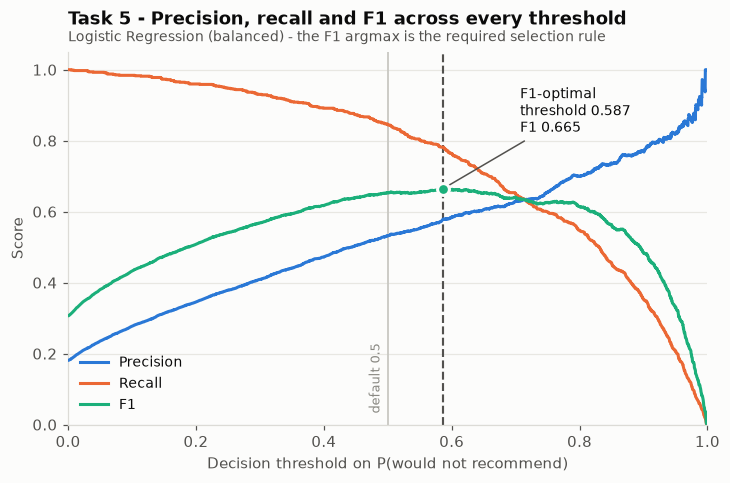

```python
# --- 5.4 Precision / recall / F1 across the threshold sweep -----------------
fig, ax = plt.subplots(figsize=(7.5, 4.4))

ax.plot(thresholds, p, color=BLUE, linewidth=2, label="Precision", zorder=3)
ax.plot(thresholds, r, color=ORANGE, linewidth=2, label="Recall", zorder=3)
ax.plot(thresholds, f1_arr, color=AQUA, linewidth=2, label="F1", zorder=4)

ax.axvline(best_threshold, color=GREY, linewidth=1.4, linestyle="--", zorder=2)
ax.scatter([best_threshold], [f1_arr[best_i]], s=60, color=AQUA,
           edgecolor="#fcfcfb", linewidth=2, zorder=5)
ax.annotate(
    f"F1-optimal\nthreshold {best_threshold:.3f}\nF1 {f1_arr[best_i]:.3f}",
    xy=(best_threshold, f1_arr[best_i]),
    xytext=(best_threshold + 0.12, f1_arr[best_i] + 0.16),
    fontsize=9, color="#0b0b0b",
    arrowprops=dict(arrowstyle="-", color=GREY, linewidth=1),
)
ax.axvline(0.5, color="#c9c8c3", linewidth=1.2, zorder=1)
ax.text(0.492, 0.03, "default 0.5", transform=ax.get_xaxis_transform(),
        ha="right", va="bottom", fontsize=8.5, color="#8a8983", rotation=90)

ax.set_ylim(0, 1.05)
ax.set_xlim(0, 1)
style_axes(ax, xlabel="Decision threshold on P(would not recommend)", ylabel="Score",
           title="Task 5 - Precision, recall and F1 across every threshold",
           subtitle=f"{best_model_name} - the F1 argmax is the required selection rule")
ax.legend(frameon=False, loc="lower left", fontsize=9)
save_fig(fig, "task5_threshold_sweep")
plt.show()
```

## Task 6 — Model Explainability

```python
rf_for_importance = fitted["Random Forest (balanced)"]
importances = rf_for_importance.feature_importances_

imp = pd.DataFrame({"feature": FEATURE_NAMES, "importance": importances})
imp["importance_pct"] = imp["importance"] / imp["importance"].sum() * 100

# --- 6.1 Top 10 individual features ----------------------------------------
top10 = imp.sort_values("importance", ascending=False).head(10).reset_index(drop=True)
top10.index = top10.index + 1

print("Top 10 features by Random Forest importance:\n")
display(top10.round({"importance": 5, "importance_pct": 3}))

RESULTS["task6"] = {
    "top10": [
        {"rank": int(i), "feature": str(row.feature),
         "importance": round(float(row.importance), 5),
         "importance_pct": round(float(row.importance_pct), 3)}
        for i, row in top10.iterrows()
    ]
}
```

```
Top 10 features by Random Forest importance:
```

|  | feature | importance | importance_pct |
| --- | --- | --- | --- |
| 1 | sentiment_polarity | 0.08990 | 8.990 |
| 2 | exclam_count | 0.02596 | 2.596 |
| 3 | tfidf__love | 0.02078 | 2.078 |
| 4 | sentiment_subjectivity | 0.01987 | 1.987 |
| 5 | tfidf__perfect | 0.01985 | 1.985 |
| 6 | tfidf__comfortable | 0.01834 | 1.834 |
| 7 | review_length | 0.01752 | 1.752 |
| 8 | tfidf__great | 0.01518 | 1.518 |
| 9 | Age | 0.01414 | 1.414 |
| 10 | tfidf__looked | 0.01401 | 1.401 |

```python
# --- 6.2 Group into exactly two families ------------------------------------
TEXT_DERIVED = set(NLP_NUMERIC) | {f for f in FEATURE_NAMES if f.startswith("tfidf__")}


def family_of(feature_name):
    return "Text-derived" if feature_name in TEXT_DERIVED else "Structured"


imp["family"] = imp["feature"].map(family_of)

family_summary = imp.groupby("family").agg(
    n_features=("feature", "size"),
    total_importance=("importance", "sum"),
)
family_summary["pct_of_total"] = (
    family_summary["total_importance"] / imp["importance"].sum() * 100
).round(2)

print("Importance by feature family:\n")
display(family_summary.round({"total_importance": 4}))

struct_pct = float(family_summary.loc["Structured", "pct_of_total"])
text_pct = float(family_summary.loc["Text-derived", "pct_of_total"])
print(f"\nStructured   : {struct_pct:.2f}% of total importance "
      f"({int(family_summary.loc['Structured', 'n_features'])} features)")
print(f"Text-derived : {text_pct:.2f}% of total importance "
      f"({int(family_summary.loc['Text-derived', 'n_features'])} features)")
print(f"\nHigher family: {'Text-derived' if text_pct > struct_pct else 'Structured'}")

# Per-feature average, to separate "this family matters" from "this family is big".
family_summary["avg_importance_per_feature"] = (
    family_summary["total_importance"] / family_summary["n_features"])
print("\nAverage importance per feature (guards against a large family winning on count alone):")
print((family_summary["avg_importance_per_feature"] * 100).round(4).to_string())

RESULTS["task6"].update({
    "structured_pct": round(struct_pct, 2),
    "text_derived_pct": round(text_pct, 2),
    "structured_n": int(family_summary.loc["Structured", "n_features"]),
    "text_derived_n": int(family_summary.loc["Text-derived", "n_features"]),
    "higher_family": "Text-derived" if text_pct > struct_pct else "Structured",
    "avg_per_feature": {k: round(float(v) * 100, 4)
                        for k, v in family_summary["avg_importance_per_feature"].items()},
})
```

```
Importance by feature family:
```

| family | n_features | total_importance | pct_of_total |
| --- | --- | --- | --- |
| Structured | 28 | 0.045 | 4.5 |
| Text-derived | 305 | 0.955 | 95.5 |

```
Structured   : 4.50% of total importance (28 features)
Text-derived : 95.50% of total importance (305 features)

Higher family: Text-derived

Average importance per feature (guards against a large family winning on count alone):
family
Structured      0.1608
Text-derived    0.3131
```

```
saved -> docs/figures/task6_feature_importance.png
```

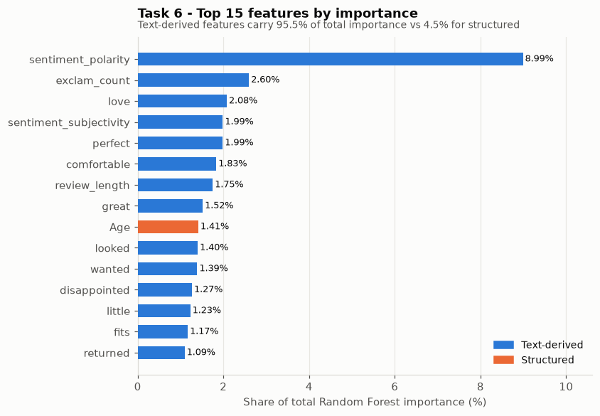

```python
# --- 6.3 Chart: top 15 features, coloured by family -------------------------
top15 = imp.sort_values("importance", ascending=True).tail(15)
colors = [BLUE if f == "Text-derived" else ORANGE for f in top15["family"]]

fig, ax = plt.subplots(figsize=(7.5, 5.6))
ax.barh(top15["feature"].str.replace("tfidf__", "", regex=False),
        top15["importance_pct"], color=colors, height=0.62, zorder=3)
for y, (v, fam) in enumerate(zip(top15["importance_pct"], top15["family"])):
    ax.text(v + 0.05, y, f"{v:.2f}%", va="center", ha="left", fontsize=8.5, color="#0b0b0b")

handles = [mpl.patches.Patch(color=BLUE, label="Text-derived"),
           mpl.patches.Patch(color=ORANGE, label="Structured")]
ax.legend(handles=handles, frameon=False, loc="lower right", fontsize=9)

ax.set_xlim(0, top15["importance_pct"].max() * 1.18)
style_axes(ax, xlabel="Share of total Random Forest importance (%)", ylabel=None,
           title="Task 6 - Top 15 features by importance",
           subtitle=f"Text-derived features carry {text_pct:.1f}% of total importance "
                    f"vs {struct_pct:.1f}% for structured",
           grid_axis="x")
save_fig(fig, "task6_feature_importance")
plt.show()
```